# Your first data science exercise

## Please hand in your submissions by March 1, 2022 (end of day)

This first session is intended as a short demo of python and important libraries for manipulating and visualizing data, namely

- numpy
- matplotlib
- pandas

Note: the exercise is structured as a series of tasks you can solve in whichever programming language you prefer, although you arestrongly encouraged to use python.

### IPython Notebooks

An IPython notebook is made up of a number of cells. Each cell can contain Python code. You can execute a cell by clicking on it and pressing [Shift-Enter] (for additional info please see the corresponding Wiki entry on OLAT, especially for OS dependent commands). When you do so, the code in the cell will be executed, and the output of the cell will be displayed beneath the cell. For example, after running the first cell the notebook looks like this:

```python
x = 5
print(x+3)
```

```
8
```

Global variables are shared between cells. Therefore, we can access **x** in the next cell.

```python
print(x+10)
```

```
15
```

## Numpy

What is numpy? A library for easily performing vectorized operations on multi-dimensional data. At its core lies the numpy **array**.

Note: in case you have not installed the numpy library, uncomment the first line before running the cell below.

```python
#! pip install numpy
import numpy as np
```

```python
# example of two 1D arrays
x = np.array([1, 2, 3, 5, 8])
y = np.array([3, 6, 9, 12, 0])

# example of two 2D arrays
a = np.array([[1, 2, 3], [5, 3, 1], [4, 8, 9]])
b = np.array([[1, 2], [2, 0], [3, 2]])
```

```python
a
```

```
array([[1, 2, 3],
       [5, 3, 1],
       [4, 8, 9]])
```

We can access the shapes of these arrays by simply calling

```python
print('shape of x:', x.shape)
print('shape of y:', y.shape)
print('shape of a:', a.shape)
print('shape of b:', b.shape)
```

```
shape of x: (5,)
shape of y: (5,)
shape of a: (3, 3)
shape of b: (3, 2)
```

One great advantage of numpy are its vectorized computations as.

```python
print('Three times x =', 3 * x)
print('x times x =', x * x)
print('x times y =', x * y)
```

```
Three times x = [ 3  6  9 15 24]
x times x = [ 1  4  9 25 64]
x times y = [ 3 12 27 60  0]
```

Useful commands for generating arrays fast...

```python
x = np.zeros(shape=(10,))
print('x:', x)

x = np.ones(shape=(10,))
print('x:', x)

x = np.arange(start=0, stop=10, step=1)
print('x:', x)

x = np.linspace(start=2.5, stop=5.35, num=5)
print('x:', x)

x = np.logspace(start=0, stop=10, num=10)
print('x:', x)
```

```
x: [0. 0. 0. 0. 0. 0. 0. 0. 0. 0.]
x: [1. 1. 1. 1. 1. 1. 1. 1. 1. 1.]
x: [0 1 2 3 4 5 6 7 8 9]
x: [2.5    3.2125 3.925  4.6375 5.35  ]
x: [1.00000000e+00 1.29154967e+01 1.66810054e+02 2.15443469e+03
 2.78255940e+04 3.59381366e+05 4.64158883e+06 5.99484250e+07
 7.74263683e+08 1.00000000e+10]
```

Mathematical operations:

```python
x = np.array([[1,2],[3,4]])
y = np.array([[5,6],[7,8]])

print('Elementwise sum: ')
print(np.add(x, y)) # eqivalent to print(x + y)

print('Elementwise difference: ')
print(np.subtract(x, y)) # eqivalent to print(x - y)

print('Elementwise product: ')
print(np.multiply(x, y)) # eqivalent to print(x * y)

print('Elementwise division: ')
print(np.divide(x, y)) # eqivalent to print(x / y)
```

```
Elementwise sum:
[[ 6  8]
 [10 12]]
Elementwise difference:
[[-4 -4]
 [-4 -4]]
Elementwise product:
[[ 5 12]
 [21 32]]
Elementwise division:
[[0.2        0.33333333]
 [0.42857143 0.5       ]]
```

Select elements which satisfy a condition. Using numpy array makes such a selection trivial!

```python
a = np.array([1,2,3,4,5,6,7,8,9])
mask = a > 4
b = a[mask]
print(b)
```

```
[5 6 7 8 9]
```

### Task 1:

Generate two arrays: array **X** has to be a sequence of 100 equally spaced numbers from 0 to 10 and array **Y** is defined as the squared sum of **X**, **X** divided by 2, and **X** times 3.

## Matplotlib

Matplotlib allows for easy visualization of data arrays from e.g. numpy or pandas.

```python
import matplotlib.pyplot as plt
```

```python
# generate some data
x = np.array([1, 2, 3, 4, 5, 6])
y = np.array([1, 2, 3, 5, 8, 13])
```

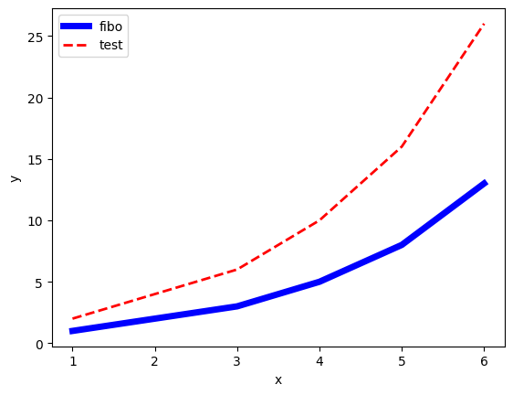

```python
# define a figure object ad plot the data
plt.figure()
plt.plot(x, y, ls='-', c='b', lw=5, label='fibo')
plt.plot(x, 2.*y, ls='--', c='r', lw=2, label='test')
# provide labels...
plt.xlabel('x')
plt.ylabel('y')
# ...and a lengend
plt.legend()

plt.show()
```

Now, generate random numbers drawn from a Normal distribution...

Note: see the documentation for the function np.random.normal (https://numpy.org/doc/stable/reference/random/generated/numpy.random.normal.html) to understand which parameters need to be given.

```python
x = np.random.normal(-1, 1, size=(5000,))
y = np.random.normal(0, 2, size=(5000,))
```

... and visualize them with a scatter plot

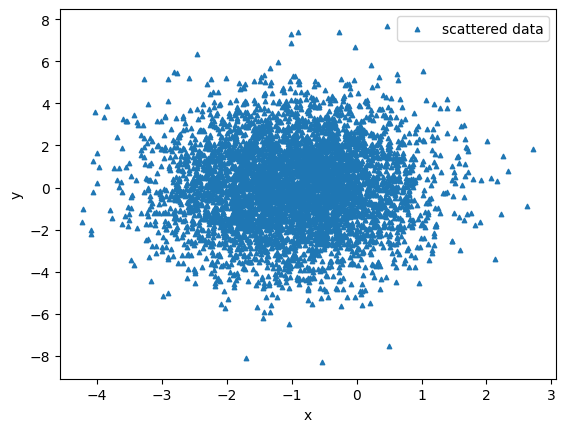

```python
plt.figure()
# the scatter plot
plt.scatter(x, y, marker='^', s=10, label='scattered data')
plt.xlabel('x')
plt.ylabel('y')
plt.legend()
plt.show()
```

Add a color code

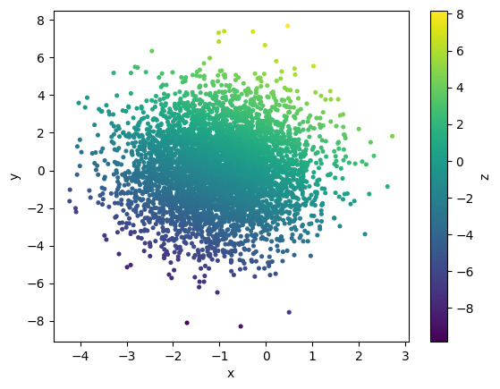

```python
z = x + y

plt.figure()
sct_plt = plt.scatter(x, y, c=z, marker='o', s=7, cmap='viridis')
cbar = plt.colorbar(sct_plt)
plt.xlabel('x')
plt.ylabel('y')
cbar.set_label('z')
plt.show()
```

Matplotlib offers easy routines for plotting 2D datasets...

```
[[1 4 2]
 [5 2 3]
 [9 6 2]]
```

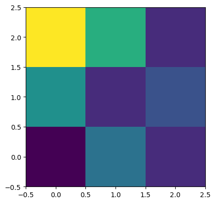

```python
a = np.array([[1, 4, 2], [5, 2, 3], [9, 6, 2]])
plt.figure()
plt.imshow(a, origin='lower')
print(a)
plt.show()
```

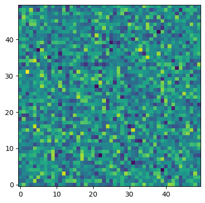

```python
x = np.random.normal(0, 1, size=(50, 50))
plt.figure()
plt.imshow(x, origin='lower')
plt.show()
```

### Task 2:

- Generate an array **X** of 1000 random, normal-distributed numbers with mean = -1 and standard deviation = 2
- Sort **X** (use, e.g., the np.sort function: https://numpy.org/doc/stable/reference/generated/numpy.sort.html)
- Define a second array **Y** that is the cube of the first one
- Plot **X** vs **Y** and provide the axis lables

### Task 3:

- Generate an array **X** of 2000 random, normal-distributed numbers with mean = 0 and standard deviation = 1
- Generate an array **Z**, with the same shape of **X**, of random, normal-distributed numbers with mean = 2 and standard deviation = 5
- Plot **X** vs **Z** as a scatter plot

### Task 4:

- Generate a *2D array* **A** of random numbers, drawn from a gaussian distribution with mean = 0 and standard deviation = 1 of size 50 x 50
- Show the image defined by **A** (use, e.g., plt.imshow)

## Pandas

Pandas offers fast operations when dealing with entire data tables (more next week). Here you are given the dataset *housing_train.csv*.

```python
import pandas as pd
```

```python
dt = pd.read_csv('housing_train.csv', sep=',')
dt.head()
```

|  | Id | MSSubClass | MSZoning | LotFrontage | LotArea | Street | Alley | LotShape | LandContour | Utilities | ... | PoolArea | PoolQC | Fence | MiscFeature | MiscVal | MoSold | YrSold | SaleType | SaleCondition | SalePrice |
| --- | --- | --- | --- | --- | --- | --- | --- | --- | --- | --- | --- | --- | --- | --- | --- | --- | --- | --- | --- | --- | --- |
| 0 | 1 | 60 | RL | 65.0 | 8450 | Pave | NaN | Reg | Lvl | AllPub | ... | 0 | NaN | NaN | NaN | 0 | 2 | 2008 | WD | Normal | 208500 |
| 1 | 2 | 20 | RL | 80.0 | 9600 | Pave | NaN | Reg | Lvl | AllPub | ... | 0 | NaN | NaN | NaN | 0 | 5 | 2007 | WD | Normal | 181500 |
| 2 | 3 | 60 | RL | 68.0 | 11250 | Pave | NaN | IR1 | Lvl | AllPub | ... | 0 | NaN | NaN | NaN | 0 | 9 | 2008 | WD | Normal | 223500 |
| 3 | 4 | 70 | RL | 60.0 | 9550 | Pave | NaN | IR1 | Lvl | AllPub | ... | 0 | NaN | NaN | NaN | 0 | 2 | 2006 | WD | Abnorml | 140000 |
| 4 | 5 | 60 | RL | 84.0 | 14260 | Pave | NaN | IR1 | Lvl | AllPub | ... | 0 | NaN | NaN | NaN | 0 | 12 | 2008 | WD | Normal | 250000 |

5 rows × 81 columns

Access column names

```python
dt.columns
```

```
Index(['Id', 'MSSubClass', 'MSZoning', 'LotFrontage', 'LotArea', 'Street',
       'Alley', 'LotShape', 'LandContour', 'Utilities', 'LotConfig',
       'LandSlope', 'Neighborhood', 'Condition1', 'Condition2', 'BldgType',
       'HouseStyle', 'OverallQual', 'OverallCond', 'YearBuilt', 'YearRemodAdd',
       'RoofStyle', 'RoofMatl', 'Exterior1st', 'Exterior2nd', 'MasVnrType',
       'MasVnrArea', 'ExterQual', 'ExterCond', 'Foundation', 'BsmtQual',
       'BsmtCond', 'BsmtExposure', 'BsmtFinType1', 'BsmtFinSF1',
       'BsmtFinType2', 'BsmtFinSF2', 'BsmtUnfSF', 'TotalBsmtSF', 'Heating',
       'HeatingQC', 'CentralAir', 'Electrical', '1stFlrSF', '2ndFlrSF',
       'LowQualFinSF', 'GrLivArea', 'BsmtFullBath', 'BsmtHalfBath', 'FullBath',
       'HalfBath', 'BedroomAbvGr', 'KitchenAbvGr', 'KitchenQual',
       'TotRmsAbvGrd', 'Functional', 'Fireplaces', 'FireplaceQu', 'GarageType',
       'GarageYrBlt', 'GarageFinish', 'GarageCars', 'GarageArea', 'GarageQual',
       'GarageCond', 'PavedDrive', 'WoodDeckSF', 'OpenPorchSF',
       'EnclosedPorch', '3SsnPorch', 'ScreenPorch', 'PoolArea', 'PoolQC',
       'Fence', 'MiscFeature', 'MiscVal', 'MoSold', 'YrSold', 'SaleType',
       'SaleCondition', 'SalePrice'],
      dtype='object')
```

Access columns by specifying their names ad create a subsample with specific columns

```python
m = dt[['SalePrice', 'YrSold']]
m.head()
```

|  | SalePrice | YrSold |
| --- | --- | --- |
| 0 | 208500 | 2008 |
| 1 | 181500 | 2007 |
| 2 | 223500 | 2008 |
| 3 | 140000 | 2006 |
| 4 | 250000 | 2008 |

### Task 5:

- Load the data table *'housing_train.csv'* as **dt**
- Create a table **dt_sub** defined as the subset of **dt** with the columns: 'YrSold', 'OverallQual', 'SaleType', 'SaleCondition', and 'SalePrice'
- Print the shape of **dt_sub**
- Produce a scatter plot of 'SalePrice' vs 'OverallQual', color-coded by 'YrSold'